# CE2 Mathematics: Probability & Statistics 2018

# Lecture 5 - Chapter 2

## Sections 2.3: Continuous Random Variables

### To launch the notebook:

- From the menu above, select `Kernel` and `Restart & Run All`.
- Make sure that the `%matplotlib inline` and `%run Codes/Lecture05.ipy` cells were executed without an error. A number will appear to the left of each (e.g. `In [1]`) if successful.
- If you prefer to follow the lecture in slide format, select the Lecture Overview cell and click on the RISE button in the menu above

### Solutions to worked problems during the lecture:

- The answers are encoded by passwords; the information regarding the format of the password can be found by hovering your mouse over the icon
- Type your answer within the quotes in `password''`, then type `Shift` and `Enter` (or click the `>| Run` button above). If you get it correct, the full solution will be displayed. If the answer is incorrect, a random string of text will appear.

```python
%matplotlib inline
```

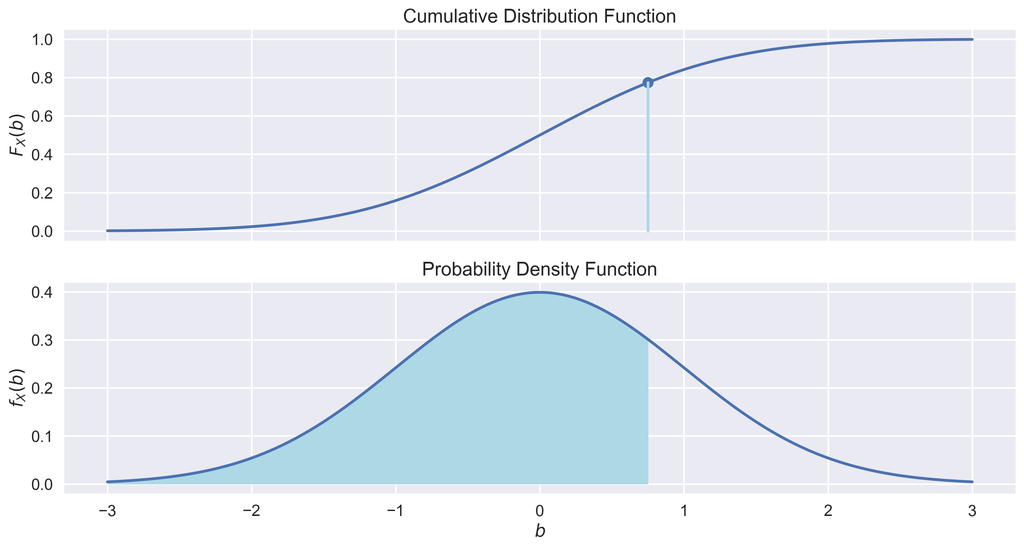

```python
%run Codes/Lecture05.ipy
```

## Lecture Overview

The lecture today will start Section 2.3 in Chapter 2 concerning **continuous** random variables. The terms we introduced are directly related to those presented for discrete random variables:

- 2.3 **Continuous Random Variables**
  - 2.3 **Cumulative Distribution Function, CDF: $F_X(x)=P(X \le x)$**
  - 2.3.1 **Expectation $E[X]$ and Variance $Var[X]$**
  - Examples: Wave function and Kinetic theory

## 2.3 Continuous Random Variables

- A random variable is **continuous** if it represents a quantity that is *measured* (as opposed to counted).
- NOTE: There is a slight change in nomenclature between discrete and continuous random variables; instead of probability mass functions (PMFs) we have probability **density** functions (PDFs). $\color{red}{\text{Both are referred to as } f_X(x)}$!
- A random variable $X$ is continuous if there exists a function $f_X(x)$, the **probability density function** (PDF) of $X$, with the property: $$P(a < X < b) = \int_{a}^{b} f_X(x) \; dx = F_X(b) - F_X(a)$$ Integrating the PDF over an interval $(a, b)$ gives the probability that $X$ takes a value *within* that interval.
- **Cumulative Distribution Function:** If we let $a \rightarrow -\infty$, the probability $F_X(a)$ becomes $0$ and we can write: $$F_X(b) = P(X \le b) = \int_{-\infty}^{b} f_X(x) \; dx$$
- **Important:** We can define the PDF $f_X(x)$ as the derivative of the CDF $F_X(x)$: $$f_X(x) = \frac{d}{dx}F_X(x)$$
- Similar to a PMF, a function $f_X(x)$ is a PDF for a continuous random variable $X$ if and only if: \begin{align} \text{1. } \quad & f_X(x) \ge 0 \text{, } \forall x \in \mathbb{R} \\ \text{2. } \quad & \int_{-\infty}^{\infty} f_X(x)\; dx = 1 \end{align}

### Relationship between PDF and CDF:

```python
display(HBox([rel_text, crit_sl]), cdf_pdf_out)
```

## 2.3.1 Expectation and Variance: Continuous RVs

- All our definitions for the moments of the PDF $f_X(x)$ yield the same results (i.e. expectation $E[X]$ and variance $Var[X]$ equations), except we replace summations with integrations! \begin{align} M_{\color{blue}{n}}^{\color{red}{c}} &= \int_{-\infty}^{\infty} (x-\color{red}{c})^{\color{blue}{n}} \; f_X(x) \; dx \\ M_{\color{blue}{0}}^{\color{red}{0}} &= \int_{-\infty}^{\infty} f_X(x) \; dx \quad \color{green}{(= 1)} \\ M_{\color{blue}{1}}^{\color{red}{0}} &= \int_{-\infty}^{\infty} x \; f_X(x) \; dx \quad \color{green}{(= E[X])} \\ M_{\color{blue}{2}}^{\color{red}{E[X]}} &= \int_{-\infty}^{\infty} (x-\color{red}{E[X]})^{\color{blue}{2}} \; f_X(x) \; dx \quad \color{green}{(= Var[X])} \end{align}
- Similarly, we define the expectation of a function $g(X)$ of $X$ to be: $$E[g(X)] = \int_{-\infty}^{\infty} g(x) f_X(x)\; dx$$
- and note that the definition of the variance derived for discrete RVs remains the same for continuous RVs: $$Var[X] = E[(X - E[X])^2] = E[X^2] - E[X]^2$$
- The remainder of our lectures in Chapter 2 will provide examples of continuous random variables, including real problems such as a wave function from PoM and residence time distributions for chemical reactors.

## 2.3 Example: PDF of a Wave Function from PoM Course

- Recall in PoM: provided a "**wave function**", $\Psi$, for the "particle in a box problem" that satisfies the Schrödinger equation: $$-\frac{\hslash^2}{2m}\frac{d^2 \Psi(x)}{dx^2} = E \Psi(x)$$
- General solution: \begin{align} \Psi_k(x) &= C \sin kx + D \cos kx \\ E_k &= \frac{k^2 \hslash^2}{2m} \end{align}
- Must satisfy the **boundary conditions** $\Psi_k(x=0)=0$ and $\Psi_k(x=L)=0$. Find the values for $D$ and $k$ that satify these B.C.s

```python
display_answer(question=0, password='n*pi/L')
```

\begin{align} x = 0: &\quad C \sin{0} + D \cos{0} = 0 \implies D = 0 \\ x = L: &\quad C \sin{(kL)} = 0 \implies kL = n \pi \implies k = \frac{n \pi}{L} \end{align}

- Resulting wave function for a particle in a box: $$\Psi_n(x) = C \sin \frac{n \pi x}{L} \;\;\;\;\; 0 \leq x \leq L \;\;\;\;\; n=1,2,..$$
  - Where $n$ is referred to as the **quantum number** $$ $$
- **Born interpretation** of the wave function
  - The **PDF** for finding a particle is: $$f_X(x) = \left| \Psi(x) \right|^2$$ $$ $$
  - What properties must $f_X(x)$ have to be a valid PDF?
- Normalising the wave function (squared): \begin{align} \int_{0}^{L} \left( \Psi_n(x) \right)^2 \; dx &= 1 \\ \int_{0}^{L} C^2 \sin^2 \frac{n \pi x}{L} \; dx &= 1 \\ \cdots &= \cdots \end{align}

```python
display_answer(question=1, password='2/L')
```

\begin{align} \frac{C^2}{2} \int_0^L \left( 1 - \cos{\frac{2 n \pi x}{L}} \right) \; dx &= 1 \\ \frac{C^2}{2} \left[ x - \frac{L}{2 n \pi} \cdot \sin{\frac{2 n \pi x}{L}} \right]_0^L &= 1 \\ \frac{C^2 L}{2} &= 1 \implies C = \sqrt{\frac{2}{L}} \end{align}

- Final PDF for a particle in a box of length $L$ (given in PoM): $$f_X(x) = \Psi_n(x)^2 = \frac{2}{L} \sin^2 \frac{n \pi x}{L} \qquad 0 \leq x \leq L$$
- How does the wave function change for different values of the quantum number $n$ (taking $L=1$ nm)?

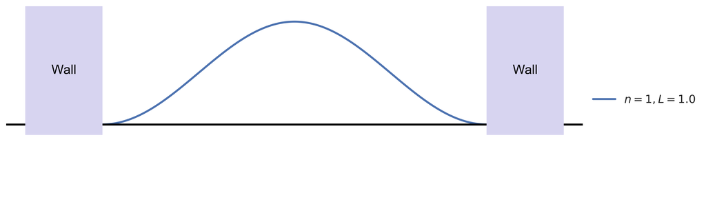

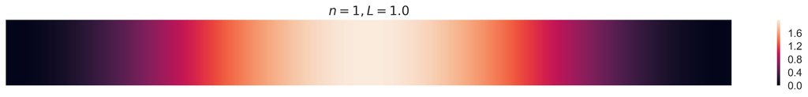

```
<function __main__.l5_particle_in_a_box_1(n)>
```

```python
wgt.interact(l5_particle_in_a_box_1, n = wgt.IntSlider(min=1,max=30,step=1,value=1,continuous_update=False,description='n:', layout=Layout(width='80%')))
```

### 2.3 Expected position of particle in a box

- Expected position of the particle = Expectation ($E[X]$; often represented in physics textbooks as $\langle x \rangle$) \begin{align} E[X] &= \int_{-\infty}^{\infty} x \; f_X(x) \; dx \\ &= \int_{0}^{L} x \; \frac{2}{L} \sin^2 \frac{n \pi x}{L} \; dx \end{align}
- Requires integration by parts (important technique to know): \begin{align} \int u \; dv &= u v - \int v \; du \\ \\ \text{where: } \; u = x \quad &\rightarrow \quad du = \cdots \\ \\ dv = \frac{2}{L} \sin^2 \frac{n \pi x}{L} & \\ dv = \frac{1}{L}\left(1 - \cos \frac{2 n \pi x}{L}\right) \quad & \rightarrow \quad v = \cdots \end{align}

```python
display_answer(question=2, password='x/L')
```

\begin{align} du &= 1 \\ v &= \frac{1}{L} \left( x - \frac{L}{2 n \pi} \cdot sin \frac{2 n \pi x}{L} \right) \end{align}

- Expected position of the particle $E[X]$: Integration by parts

\begin{align} uv &= \cdots \\ \int v \; du &= \cdots \end{align}

```python
display_answer(question=3, password='L/2')
```

\begin{align} uv &= \left[ \frac{x^2}{L} - \frac{x}{2 n \pi} \cdot \sin{\frac{2 n \pi x}{L}} \right]_0^L \\ &= (L - 0) - (0) = L \\ \int v \; du &= \frac{1}{L} \int_0^L \left( x - \frac{L}{2 n \pi} \cdot \sin{\frac{2 n \pi x}{L}} \right) \; dx \\ &= \frac{1}{L} \left[ \frac{x^2}{2} + \frac{L^2}{4 n^2 \pi^2} \cdot \cos{\frac{2 n \pi x}{L}} \right]_0^L \\ &= \frac{L^2}{2L} = \frac{L}{2} \end{align}

- Expected position of a particle in a box: $E[X]$ $$E[X] = L - \frac{L}{2} = \frac{L}{2}$$
  - Notice this is independent of the quantum number (contrast to plotted PDFs for different values for $n$)
  - How does this compare with classical mechanics ($n \rightarrow \infty$)?

```python
display_answer(question=4, password='L/2')
```

\begin{align} \textit{(Uniform) } \quad f_X^u(x) &= \frac{1}{L} \\ E[X] &= \int_0^L x \cdot f_x^u(x) \; dx = \frac{1}{L} \int_0^L x \; dx \\ &= \frac{1}{L} \cdot \frac{L^2}{2} = \frac{L}{2} \end{align}

### 2.3 Variance in the position of a particle in a box

- How about the variance? $Var[X] = E[X^2] - E[X]^2$ \begin{align} E[X^2] &= \int_{-\infty}^{\infty} x^2 f_X(x) \; dx \\ &= \int_{0}^{L} x^2 \; \frac{2}{L} \sin^2 \frac{n \pi x}{L} \; dx \end{align}
- Will require integration by parts twice (see Lecture Notes for wrist-breaking details) \begin{align} E[X^2] &= L^2 - \left[ \frac{2L^2}{3} + \frac{L^2}{2 n^2 \pi^2} \right] \\ &= \frac{L^2}{3} - \frac{L^2}{2 n^2 \pi^2} \end{align}
- Collecting terms we have the final solution for Variance: \begin{align} Var[X] &= E[X^2] - E[X]^2 \\ &= \frac{L^2}{3} - \frac{L^2}{2 n^2 \pi^2} - \left(\frac{L}{2}\right)^2 \\ &= \frac{L^2}{12} - \frac{L^2}{2 n^2 \pi^2} \\ Var[X] &= \frac{L^2}{2} \left(\frac{1}{6} - \frac{1}{n^2 \pi^2} \right) \end{align}
- Pause and Reflect 1: How does the variance change as a function of $n$? Does this make intuitive sense?
- Pause and Reflect 2: How do these results for the variance compare to a uniform distribution (in the limit of $n$)?

```python
display_answer(question=5, password='consistent')
```

\begin{align} \textbf{P&R 1:} &\\ &\text{Min when $n = 1$} \implies \frac{1}{n^2 \pi^2} = \begin{cases} 0.101 & n = 1 \\ 0.025 & n = 2 \end{cases} \\ \textbf{P&R 2:} &\\ &\lim_{n \to \infty} Var[X] = \frac{L^2}{12} \end{align}

### Comparing the PDF for the Wave Function as $n$ increases to the classical mechanics solution

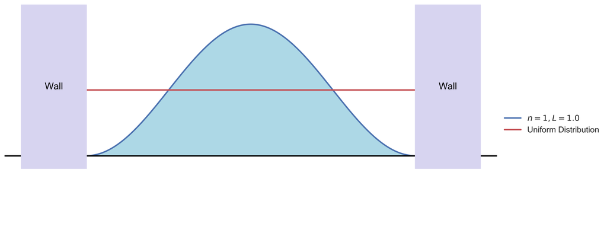

```
<function __main__.l5_particle_in_a_box_2(n)>
```

```python
wgt.interact(l5_particle_in_a_box_2, n = wgt.IntSlider(min=1,max=30,step=1,value=1,continuous_update=False,description='n:', layout=Layout(width='80%')))
```

## 2.3 Example: Collision times in kinetic theory

- For a molecule travelling at velocity $v$, let us define the following **survival probability**: \begin{align} P(t) &= \text{Probability that a molecule survives} \\ & \quad \text{until a time $t$ } \textit{without} \text{ a collision} \end{align}
- We can reason the following boundary conditions about $P(t)$: \begin{align} P(t = 0) &= 1 \\ P(t \rightarrow \infty) &= 0 \end{align}

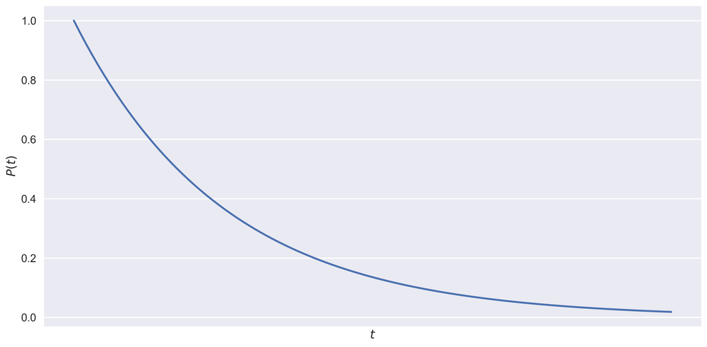

```python
x = np.linspace(0, 4, 100); plt.plot(x, expon.pdf(x)); plt.xticks([]); plt.xlabel('$t$'); plt.ylabel('$P(t)$');
```

- We can also define the probability that a collision takes place over a time interval from $t$ to $t + dt$.
- Let $w$ denote the **collision rate** (i.e. the probability per unit time that a molecule suffers a collision). Then: \begin{align} w \cdot dt &= \textit{Probability} \text{ that a molecule experiences a} \\ & \quad \text{collision between times $t$ and $t+dt$} \end{align}
- Assumption: Collision rate $w$ is independent of past history of the molecule

[figure not shown]

- Analogous to our 1-D Random Walk example, we can express the survival probability $P(t)$ as a function of the probability that a collision takes place (i.e. $w \cdot dt$) over a given time interval: $$P(t+dt) = \cdots$$
- We can also express $P(t+dt)$ using a Taylor Series expansion: $$P(t+dt) = \cdots$$
- Equating the two expressions and solving for $P(t)$ we get the following survival probability: $$ \cdots $$

```python
display_answer(question=6, password='e^(-wt)')
```

\begin{align} P(t + dt) &= P(t) \cdot (1 - w \cdot dt) \\ P(t + dt) &= P(t) + \frac{d P(t)}{dt} dt \qquad \textit{(Taylor Series)} \\ \\ \frac{d P(t)}{dt} dt &= - P(t) w \; dt \qquad \textit{(Equating two expressions)} \\ \implies \int_1^P \frac{d P(t)}{P(t)} &= - \int_0^t w \; dt \\ \ln{P} - \ln{0} &= - wt \\ P(t) &= e^{-wt} \end{align}

- Recall that $P(t)$ represents the probability the molecule *survives* from time zero until time $t$ without a collision. Thus, the probability that the molecule *collides for the first time* during the time interval $(0,t)$ is equal to: $$F(t) = \cdots$$
- Note that $F(t)$ is a cumulative distribution function (CDF)! Thus we can define the probability density function (PDF) for collisions as: $$f(t) = \frac{dF(t)}{dt} = \cdots$$
- And from this we can compute a mean collision time: $$ \cdots $$

```python
display_answer(question=7, password='1/w')
```

\begin{align} F(t) &= 1 - P(t) \\ f(t) &= \frac{dF(t)}{dt} = - \frac{dP(t)}{dt} = w e^{-wt} \\ E[T] &= \int_0^\infty t \cdot w e^{-wt} \; dt \\ \hline & \qquad \int u \; dv = uv - \int v \; du \\ & \qquad u = t \to du = 1 \\ & \qquad dv = w e^{-wt} \to v = -w^{-wt} \\ \hline E[T] &= \left[ -t e^{-wt} \right]_0^\infty + \int_0^\infty e^{-wt} \; dt \\ &= \left[ - \frac{1}{w} e^{-wt} \right]_0^\infty = \frac{1}{w} \end{align}

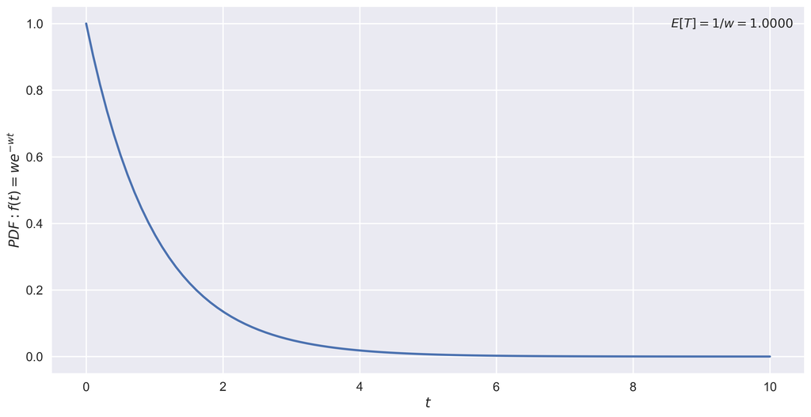

```
<function __main__.l5_collision_expo(w)>
```

```python
wgt.interact(l5_collision_expo, w = wgt.FloatSlider(min=0.5,max=10,step=0.1,value=1,continuous_update=False,description='w:', layout=Layout(width='80%')))
```

## Summary

- This lecture introduced continuous RVs and defined:
- Probability Density Function, PDF, $f_X(x)$: $$P(a < X < b) = \int_{a}^{b} f_X(x) \; dx$$
- Cumulative Distribution Function, CDF, $F_X(x)$: $$F_X(b) = P(X \le b) = \int_{-\infty}^{b} f_X(x) \; dx$$
- We also defined an important link between the PDF and CDF: $$f_X(x) = \frac{d}{dx}F_X(x)$$
- We reviewed examples that illustrate how to compute $E[X]$ and $Var[X]$ for continuous random variables. Next lecture we will apply these same tools to the analysis of residence time distributions in chemical reactors.